# tutorial_Deadtrees

Author

Teja Kattenborn (teja.kattenborn@geosense.uni-freiburg.de); Joachim Maack

Published

January 21, 2025

# Simulating tree mortality patterns against climate change scenarios

Here, we will simulate how recent mortality dynamics may have looked like under future climate scenarios.

- We will perform these simulations using machine learning models (random forest). These models learned the relationship of present tree mortality patterns with present soil, topographic and climate data.
- By running the model again with future climate data, we attempt to simulate how tree mortality of the last years might have looked like under future conditions. Thus, this might give us an idea if we can expect more sever mortality dynamics under future conditoons.
- Thereby, we will also consider different[Shared Socioeconimic Pathways (SSPs)](https://en.wikipedia.org/wiki/Shared_Socioeconomic_Pathways), which are different scenarios of human behaviour (more or less CO2 emissions). More specifically, we will use SSP2 and SSP5.
  - SSP2 (Middle of the Road):
    - CO₂ Emissions (2100): ~25–40 GtCO₂/year.
    - Cumulative Emissions (2020–2100): ~1,200–1,600 GtCO₂.
    - Peak Warming: ~2.5–3°C by 2100 (depending on mitigation efforts).
  - SSP5 (Fossil-Fueled Development):
    - CO₂ Emissions (2100): ~80–100 GtCO₂/year.
    - Cumulative Emissions (2020–2100): ~2,500–3,500 GtCO₂.
    - Peak Warming: ~4–5°C by 2100 (high-emission scenario).

These future climate scenarios are obtained from [WorldClim](https://www.worldclim.org/data/cmip6/cmip6climate.html), future climate projections are based on General Circulation Models (GCMs), which simulate climate processes using historical and current climate

## Train Model on current conditions

The first step is to identify, collect and prepare some influential variables (like in the last week)

Set working directory

Loading the raster files and start exploring the data with some plotting

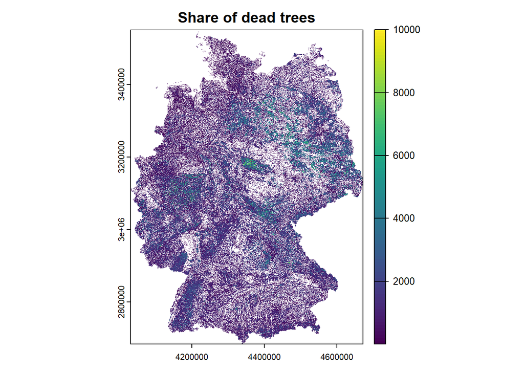

## Modelling tree mortality with climatic and topographic data

Lets check if we can model the relationship between environmental data and tree-mortality. We have selected environmental data, consisting of

- [SRTM](https://www.earthdata.nasa.gov/data/instruments/srtm) (NASA space shuttle topography mission)
- [Worldclim](https://www.worldclim.org/data/index.html)
- [SoilGrids](https://soilgrids.org/)

What will we do?

1. Prepare the data for model training (merge data into a common raster stack).
2. Extract sample data from both the tree mortality map (response variable) and the climate data (predictors).
3. Train a Random Forest model and evaluate the importance of the predictors.
4. Predicting the tree mortality for future climate scenarios (2040, 2060, 2080, 2100)

### 1. Prepare Your Data

### 2. Sample predictor and response values

```r
# combine predictors (environmental variables) and response (tree mortality)
stack_updated = c(preds_raster_stack, raster_stack$max)

# Extract values for the response (tree mortality)
set.seed(42)
sampled_values = spatSample(stack_updated, size = 2000, method = "random", xy = TRUE, na.rm=TRUE)

# Check the sampled values
head(sampled_values)
```

```
        x       y wc2.1_30s_bio_1 wc2.1_30s_bio_12 wc2.1_30s_bio_15
1 4249266 2916430        9.351789         956.0207         14.83053
2 4599466 3334830        8.617581         524.2516         25.43239
3 4501866 3036430        5.106870         935.3655         18.93643
4 4406166 2808730        8.102858         861.1170         29.83681
5 4197166 2765130        6.185803        1187.2266         14.36141
6 4464066 2887230        8.236206         692.3408         23.53127
  wc2.1_30s_bio_17 wc2.1_30s_bio_7 sand_100-200cm_mean     slope
1        212.99664        25.47134            215.6873  4.720386
2         96.95466        26.40887            589.2689  4.906311
3        192.20744        23.43409            500.0538  7.646969
4        145.15697        26.82508            365.0114  4.888646
5        256.14984        25.41114            301.9183 18.955265
6        131.07027        26.96822            314.2948  9.238043
  species_class_sum  max
1                 3 1748
2                 9 2633
3                 8 3064
4                16 1100
5                 8 2295
6                 3 1503
```

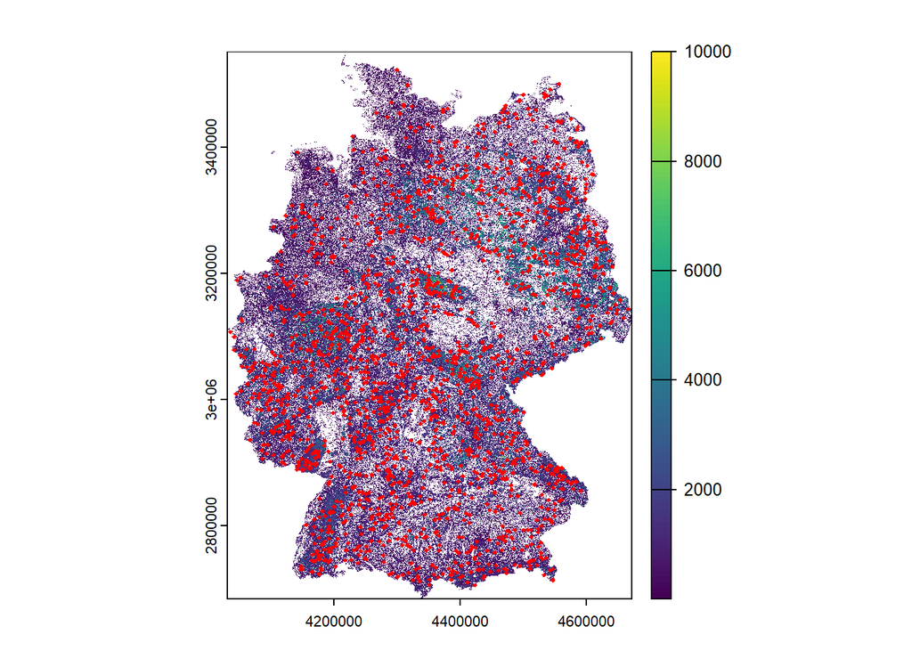

```r
plot(raster_stack$max)
points(sampled_values$x, sampled_values$y, col = "red", pch = 18, cex = 0.5)
```

### 3. Train a Random Forest Model

What is a [RandomForest](https://en.wikipedia.org/wiki/Random_forest#:~:text=Random%20forests%20are%20a%20way,performance%20in%20the%20final%20model.)? RandomForest is a machine learning model. Its underlying principle is simple; it builds on decision trees. Each branch of a tree is a decision based on a predictor (e.g. a temperature value from WorldClim or Slope from SRTM). After one branch follows another branch with a subsequent decision. The special thing about randomForest is that it creates hundreds of such trees, selects the best ones and averages there result. This “democratic” majority vote makes this method so robust and its simplicity makes it so efficient. This is why for years, randomForest is one of the most effective machine learning methods for tabular data.

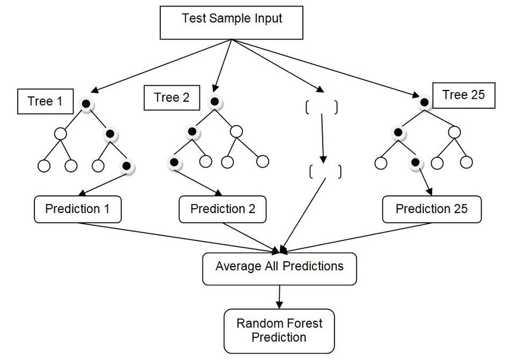

Lets train a randomForest. We will train the model a few times and check if the results (explained variance, importance of the predictors) change. Why may this happen? What influence has the sample size? You could also check the correlation between the predictors and remove one if the it exceeds 0.7.

```r
# Define the response variable (tree mortality) and predictors (climate data)
response = sampled_values$max

# remove uncessesary variables (e.g. the x and y location)
sampled_values$species_class_sum = as.factor(sampled_values$species_class_sum)
head(sampled_values[, -c(1,2,11)])
```

```
  wc2.1_30s_bio_1 wc2.1_30s_bio_12 wc2.1_30s_bio_15 wc2.1_30s_bio_17
1        9.351789         956.0207         14.83053        212.99664
2        8.617581         524.2516         25.43239         96.95466
3        5.106870         935.3655         18.93643        192.20744
4        8.102858         861.1170         29.83681        145.15697
5        6.185803        1187.2266         14.36141        256.14984
6        8.236206         692.3408         23.53127        131.07027
  wc2.1_30s_bio_7 sand_100-200cm_mean     slope species_class_sum
1        25.47134            215.6873  4.720386                 3
2        26.40887            589.2689  4.906311                 9
3        23.43409            500.0538  7.646969                 8
4        26.82508            365.0114  4.888646                16
5        25.41114            301.9183 18.955265                 8
6        26.96822            314.2948  9.238043                 3
```

```r
predictors = sampled_values[, -c(1,2,11)]  # All columns except the first one (response variable)

# Train the Random Forest model
# What does the argument ntree? Read the help.

rf_model = randomForest(x = predictors, y = response, importance = TRUE, ntree = 500)

# Check the model results
print(rf_model)
```

```
Call:
 randomForest(x = predictors, y = response, ntree = 500, importance = TRUE)
               Type of random forest: regression
                     Number of trees: 500
No. of variables tried at each split: 2

          Mean of squared residuals: 960575.6
                    % Var explained: 37.62
```

### 4. Permutation Test

In a Random Forest importance plot, %IncMSE (Percentage Increase in Mean Squared Error) is a measure of variable importance. It quantifies how much worse the model’s predictions become (in terms of Mean Squared Error, MSE) when the values of a specific predictor variable are randomly permuted.

During the calculation of variable importance, the values of a predictor variable are permuted (shuffled randomly) across all observations, breaking the relationship between the predictor and the response.

IncNodePurity (Increase in Node Purity) is another measure of variable importance used in Random Forest models. It is based on the improvement in the model’s ability to correctly classify or predict data (purity) that results from splitting a decision tree using a specific variable.

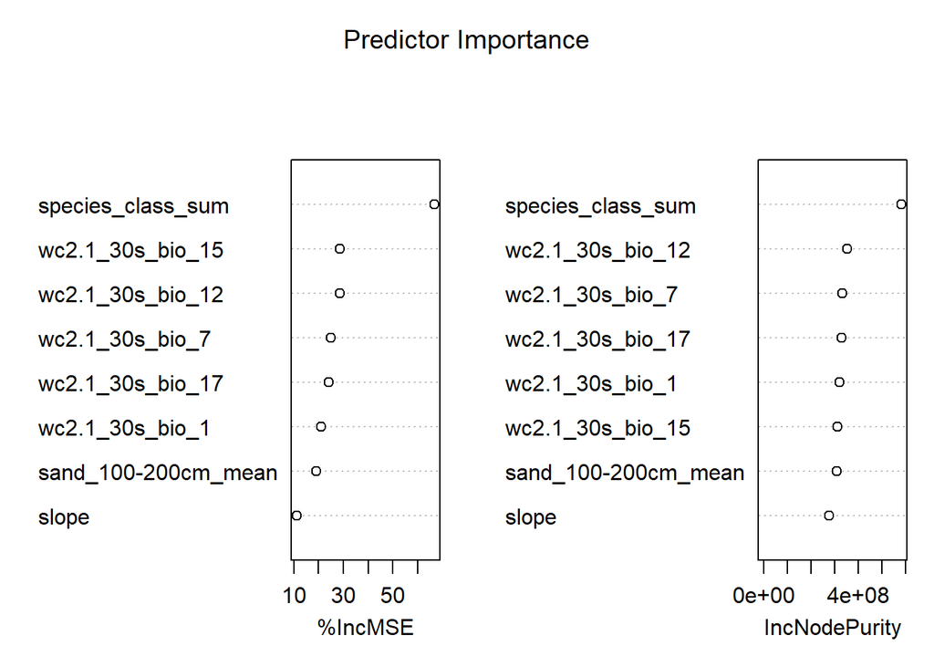

```r
varImpPlot(rf_model , sort = TRUE  , main = "Predictor Importance" )
```

You could also check the correlation between the predictors and remove one if the it exceeds +-0.7.

Further details on the WorldClim data (bio_.*) is available [here](https://www.worldclim.org/data/bioclim.html).

```r
#library(ggcorrplot)

# Visualize the correlation matrix

head(sampled_values[, -c(1,2,10,11)])
```

```
  wc2.1_30s_bio_1 wc2.1_30s_bio_12 wc2.1_30s_bio_15 wc2.1_30s_bio_17
1        9.351789         956.0207         14.83053        212.99664
2        8.617581         524.2516         25.43239         96.95466
3        5.106870         935.3655         18.93643        192.20744
4        8.102858         861.1170         29.83681        145.15697
5        6.185803        1187.2266         14.36141        256.14984
6        8.236206         692.3408         23.53127        131.07027
  wc2.1_30s_bio_7 sand_100-200cm_mean     slope
1        25.47134            215.6873  4.720386
2        26.40887            589.2689  4.906311
3        23.43409            500.0538  7.646969
4        26.82508            365.0114  4.888646
5        25.41114            301.9183 18.955265
6        26.96822            314.2948  9.238043
```

```r
predictors = sampled_values[, -c(1,2,11)]  # All columns except the first one (response variable)
predictors_cor = sampled_values[, -c(1,2,10,11)]  # All columns except the first one (response variable)

cor_matrix = cor(predictors_cor, use = "complete.obs")
cor_matrix
```

```
                    wc2.1_30s_bio_1 wc2.1_30s_bio_12 wc2.1_30s_bio_15
wc2.1_30s_bio_1          1.00000000      -0.63147337      -0.12653644
wc2.1_30s_bio_12        -0.63147337       1.00000000      -0.01439923
wc2.1_30s_bio_15        -0.12653644      -0.01439923       1.00000000
wc2.1_30s_bio_17        -0.57670446       0.95488410      -0.28636404
wc2.1_30s_bio_7          0.06656592      -0.23502351       0.45112581
sand_100-200cm_mean      0.25707839      -0.43229288       0.29188215
slope                   -0.39490381       0.51321582      -0.08217622
                    wc2.1_30s_bio_17 wc2.1_30s_bio_7 sand_100-200cm_mean
wc2.1_30s_bio_1           -0.5767045      0.06656592          0.25707839
wc2.1_30s_bio_12           0.9548841     -0.23502351         -0.43229288
wc2.1_30s_bio_15          -0.2863640      0.45112581          0.29188215
wc2.1_30s_bio_17           1.0000000     -0.32308241         -0.49442315
wc2.1_30s_bio_7           -0.3230824      1.00000000          0.03575321
sand_100-200cm_mean       -0.4944231      0.03575321          1.00000000
slope                      0.5135656     -0.12818675         -0.41031529
                          slope
wc2.1_30s_bio_1     -0.39490381
wc2.1_30s_bio_12     0.51321582
wc2.1_30s_bio_15    -0.08217622
wc2.1_30s_bio_17     0.51356564
wc2.1_30s_bio_7     -0.12818675
sand_100-200cm_mean -0.41031529
slope                1.00000000
```

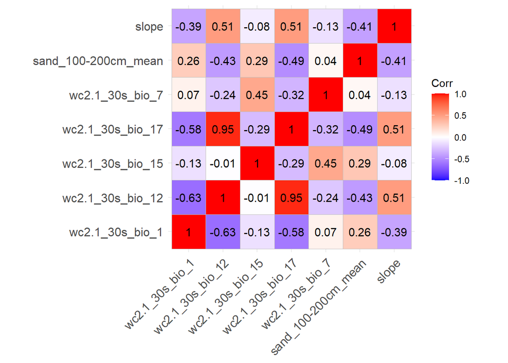

```r
ggcorrplot(cor_matrix, lab = TRUE)
```

### 5. Evaluate the dependencies of individual predictors to response

Next, we can calculate the effect of each predictor on the mortality. In easy words, the effect of a single variable is calculated based on its effect on the prediction.

#### Slope

The response is given in the original values (1-10000). Divide by 100 for %-values

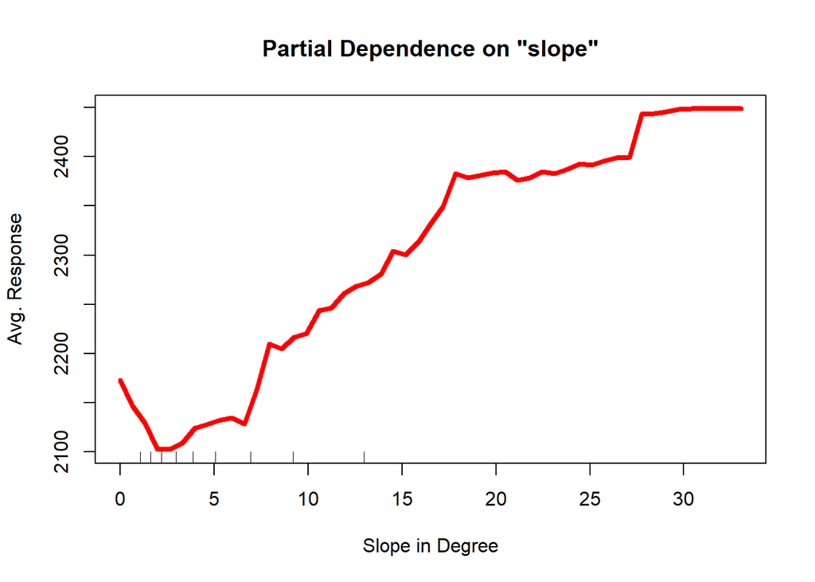

```r
# Evaluate the predictors effects
partialPlot(rf_model, predictors, "slope", "1",xlab="Slope in Degree", ylab="Avg. Response",lwd=4,col="red")
```

#### Soil: Sand 100-200 cm

The response is given in the original values (1-10000). Divide by 100 for %-values

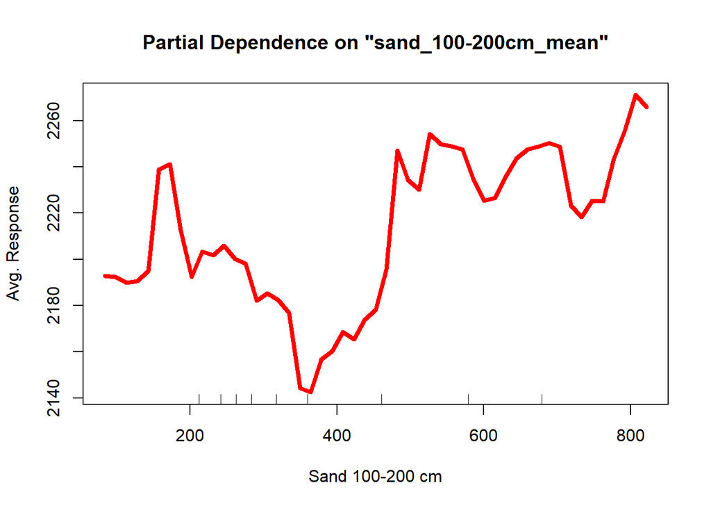

```r
# Evaluate the predictors effects
partialPlot(rf_model, predictors, "sand_100-200cm_mean", "1",xlab="Sand 100-200 cm", ylab="Avg. Response",lwd=4,col="red")
```

#### Temperature Annual Range (wc2.1_30s_bio_7)

The response is given in the original values (1-10000). Divide by 100 for %-values

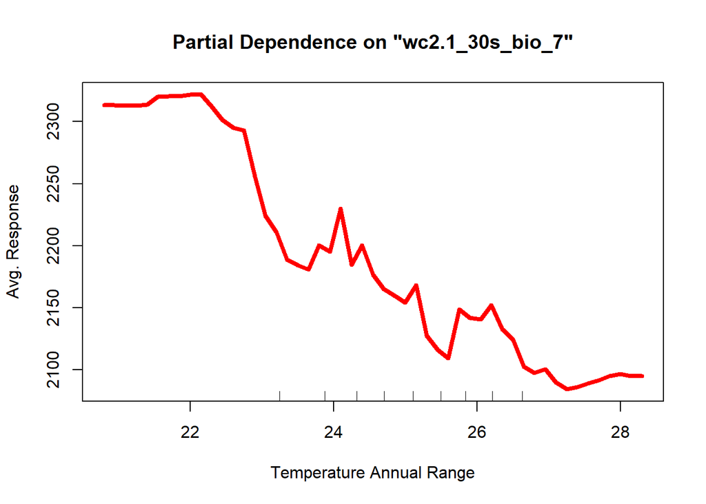

```r
# Evaluate the predictors effects
partialPlot(rf_model, predictors, "wc2.1_30s_bio_7", "1",xlab="Temperature Annual Range", ylab="Avg. Response",lwd=4,col="red")
```

#### Precipitation Seasonality (wc2.1_30s_bio_15)

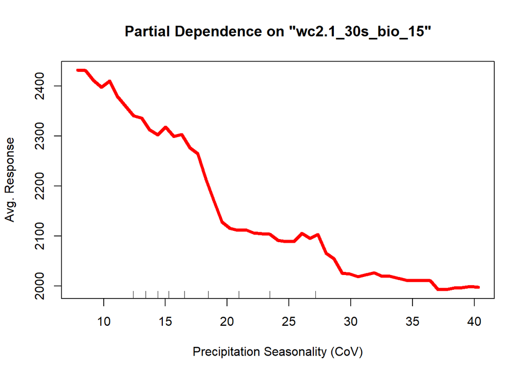

```r
# Evaluate the predictors effects
partialPlot(rf_model, predictors, "wc2.1_30s_bio_15" , "1",xlab="Precipitation Seasonality (CoV)", ylab="Avg. Response",lwd=4,col="red")
```

#### Annual Mean Temperature (wc2.1_30s_bio_1)

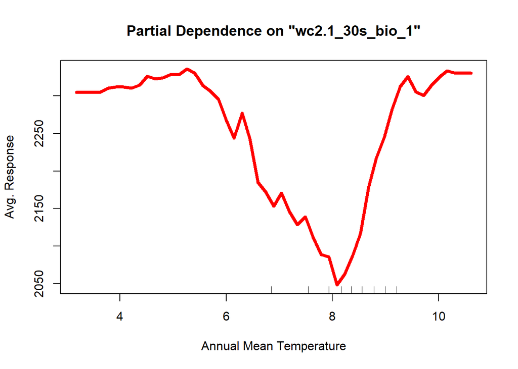

```r
# Evaluate the predictors effects
partialPlot(rf_model, predictors, "wc2.1_30s_bio_1", "1",xlab="Annual Mean Temperature", ylab="Avg. Response",lwd=4,col="red")
```

#### Annual Precipitation (wc2.1_30s_bio_12)

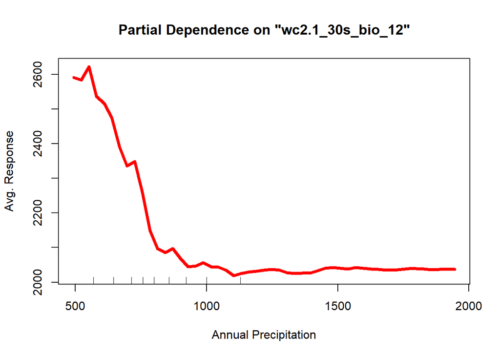

```r
# Evaluate the predictors effects
partialPlot(rf_model, predictors, "wc2.1_30s_bio_12" , "1",xlab="Annual Precipitation", ylab="Avg. Response",lwd=4,col="red")
```

#### Precipitation of Driest Quarter (wc2.1_30s_bio_17)

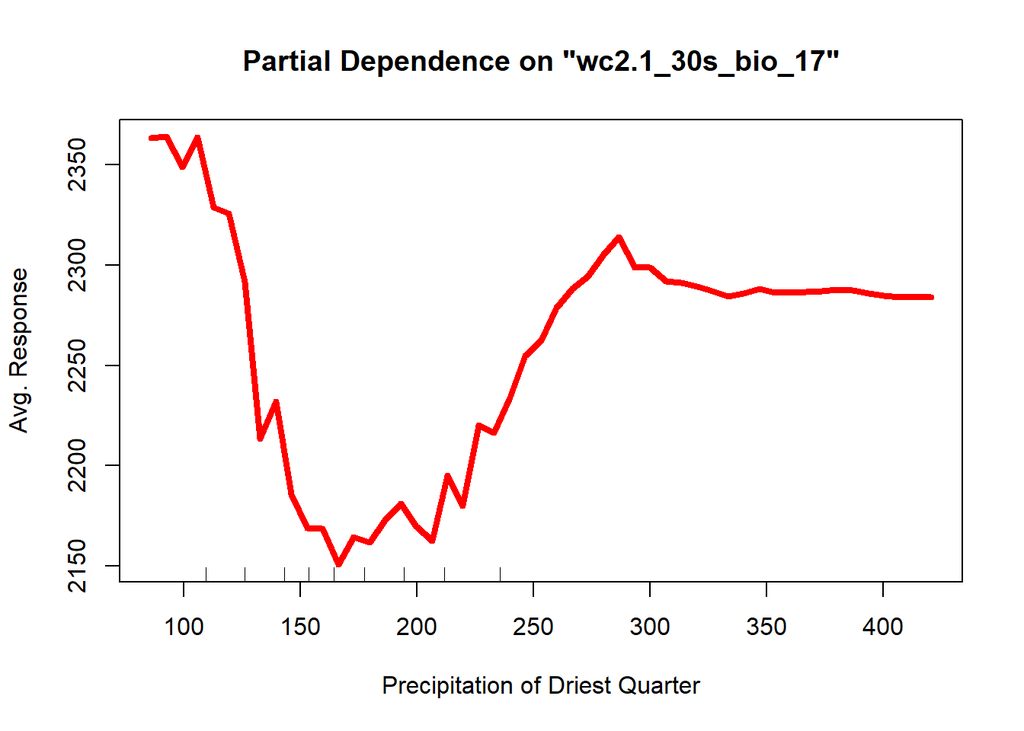

```r
# Evaluate the predictors effects
partialPlot(rf_model, predictors, "wc2.1_30s_bio_17" , "1",xlab="Precipitation of Driest Quarter", ylab="Avg. Response",lwd=4,col="red")
```

### 6. Predict future states (optional)

The following steps will take some time for processing. However, we have pre-processed the model results. Thus, you can skip 6. and move on to 7.

Our model is now trained with actual data. In the following we will load possible future states of our predictor variables and present them to your model. Only the climate variables will change for this model, the soil and topographic variables will stay the same.

#### (optional) Load new data for extrapolation

```r
# Specify the folder containing the raster files of the predictors
folder_preds = "extrapol_2040_ssp2"

# List all raster files of the predictors in the folder (e.g., .tif files)
raster_files_ex = list.files(folder_preds, pattern = "\\.tif$", full.names = TRUE)

# Load and stack the rasters
raster_stack_ex = rast(raster_files_ex)
```

#### (optional) Predicting future tree mortality

```r
species_mask = rast(paste0(folder_preds,"/tree_species_class.tif"))

# New dataset for prediction
new_data = raster_stack_ex

#new_data = classify(new_data, rcl = cbind(NA, 0))
# Ensure the new data has the same structure as the training data
# Check the column names and factor levels if applicable
names(new_data) = names(predictors)

names(predictors)

new_data = classify(new_data, rcl = cbind(NA, 2)) #RandomForest cant handle NA values

new_data$species_class_sum = as.factor(new_data$species_class_sum)
predictions = terra::predict(model=rf_model, object=new_data, parallel = TRUE)

predictions = mask(predictions, species_mask)


writeRaster(predictions, "predicted_dead_trees_2040_ssp2.tif", overwrite = TRUE)
```

### 7. Analyzing the results

#### Plotting the tree mortality patterns for the different decades

Now we will analyze the results of the predictions. The predictions are based on the HadGEM3-GC31 model using two different [SSP](https://de.wikipedia.org/wiki/Shared_Socioeconomic_Pathway) (Shared Socioeconomic Pathway). HadGEM3 simulates how the Earth’s climate behaves under different scenarios. It helps predict how things like temperature, rainfall, and sea levels might change in the future, based on various factors like greenhouse gas emissions. We used HadGEM3 predictions on SSP2 and SSP5.

- SSP2 is known as the “middle of the road” scenario. It represents a future where global development follows a moderate path with no major disruptions or significant shifts in either direction.
- SSP5 represents a scenario where the world continues a high-emission, fossil-fuel-driven economic development, with significant technological advancements but also with rising challenges in terms of environmental degradation.

We pre-processed raster files using both scenarios for the years 2040, 2060, 2080 and 2100.

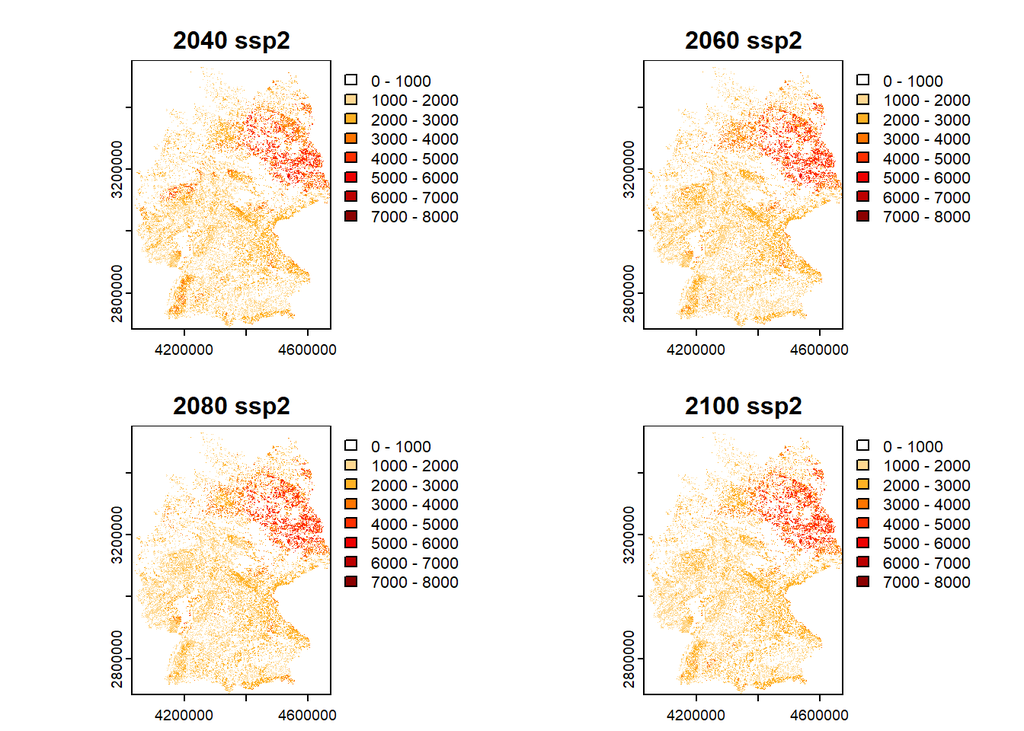

```r
# Specify the folder containing the raster files of the predictors
folder_preds = "Predictions_Deadtrees"

# List all raster files of the predictors in the folder (e.g., .tif files)
raster_files_preds = list.files(folder_preds, pattern = "\\.tif$", full.names = TRUE)

# Load and stack the rasters
raster_stack_preds = rast(raster_files_preds)

# Define a custom color ramp
color_ramp = colorRampPalette(c("white", "orange", "red", "darkred"))

# Create breaks to emphasize values above 5000
breaks = c(0, 1000, 2000, 3000, 4000, 5000, 6000, 7000, 8000)


# Userdefined headings
titles_ssp2 = c("2040 ssp2", "2060 ssp2", "2080 ssp2", "2100 ssp2")
titles_ssp5 = c("2040 ssp5", "2060 ssp5", "2080 ssp5", "2100 ssp5")

plot(raster_stack_preds[[c(1,3,5,7)]], main = titles_ssp2, col = color_ramp(length(breaks)-1), breaks = breaks)
```

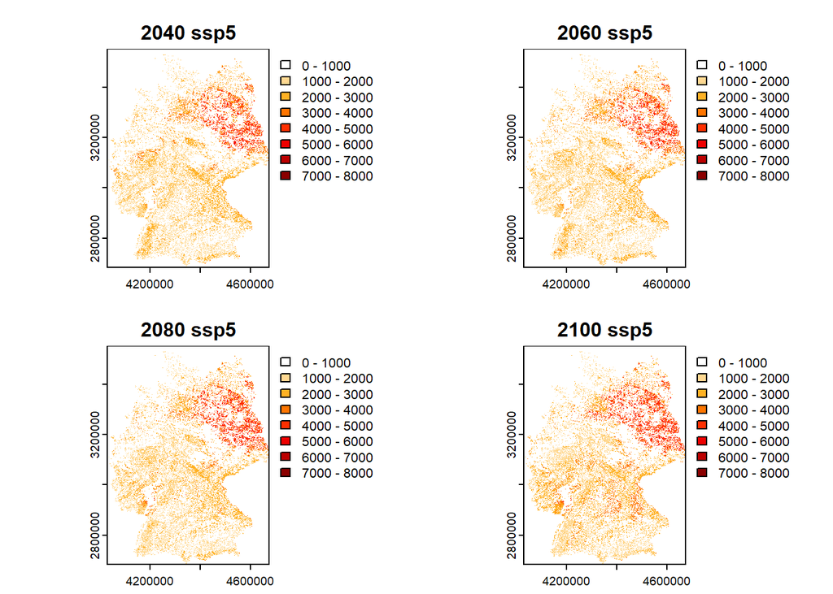

```r
plot(raster_stack_preds[[c(2,4,6,8)]], main = titles_ssp5, col = color_ramp(length(breaks)-1), breaks = breaks)
```

The differences are not so clear. Let´s try with a threshold and only show tree mortality greater than 30% cover per pixel:

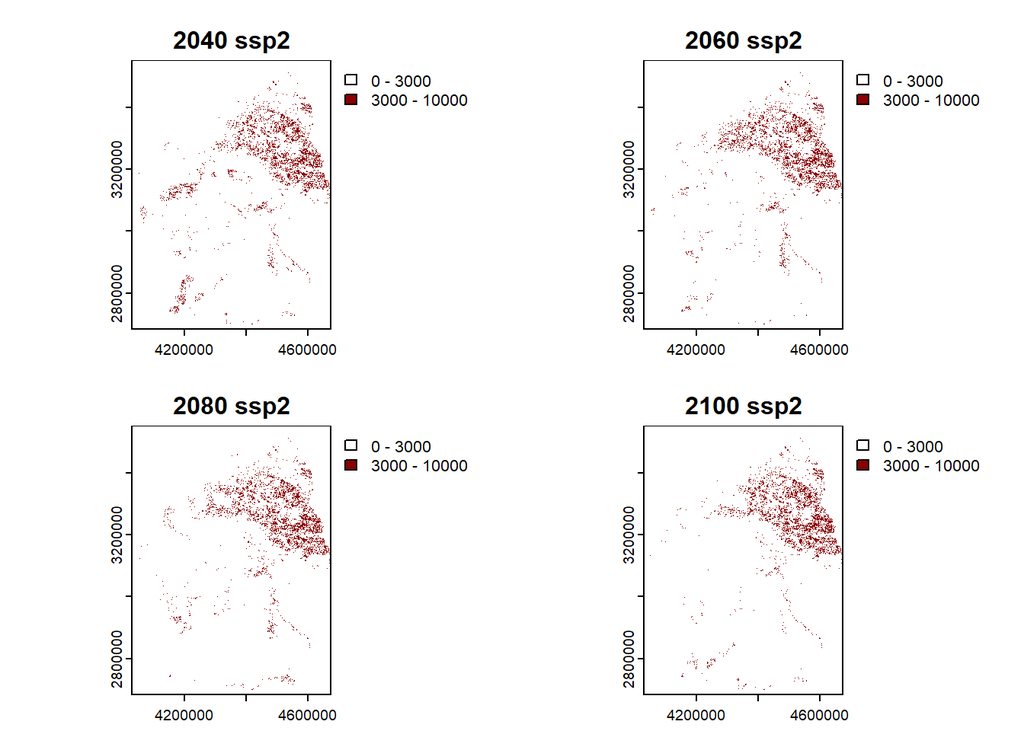

```r
# Define a custom color ramp here for a certain threshold
color_ramp = colorRampPalette(c("white", "darkred"))

# Create breaks to highlight a certain threshold
breaks = c(0, 3000, 10000)


# Userdefined headings
titles_ssp2 = c("2040 ssp2", "2060 ssp2", "2080 ssp2", "2100 ssp2")
titles_ssp5 = c("2040 ssp5", "2060 ssp5", "2080 ssp5", "2100 ssp5")


plot(raster_stack_preds[[c(1,3,5,7)]], main = titles_ssp2, col = color_ramp(length(breaks)-1), breaks = breaks)
```

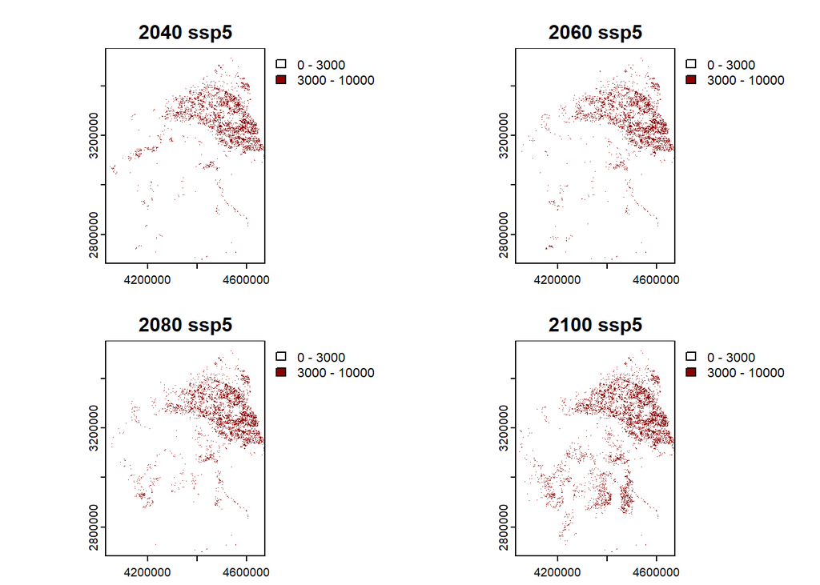

```r
plot(raster_stack_preds[[c(2,4,6,8)]], main = titles_ssp5, col = color_ramp(length(breaks)-1), breaks = breaks)
```

#### Difference maps ssp5

Now we want to visualize the difference between the different scenarios (SSP2 vs SSP5) for the year 2100. Would we observe more or less tree mortality with high CO2 output scenario?

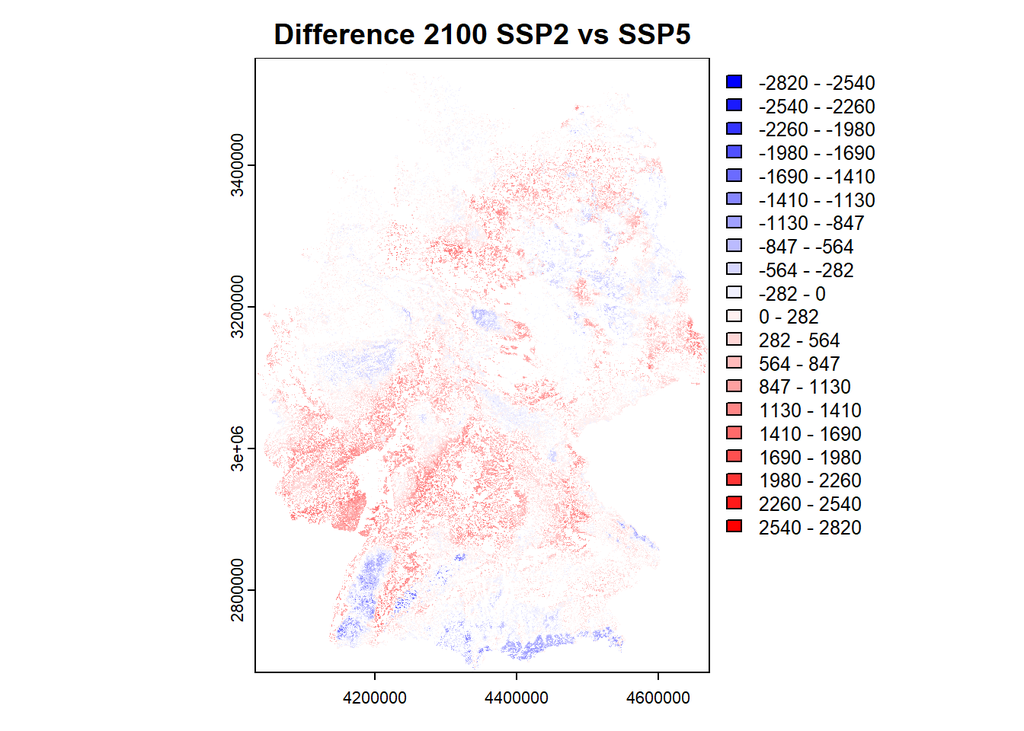

```r
# Calculating differences
diff_2100 <- raster_stack_preds[[8]] - raster_stack_preds[[7]]

# Define a custom blue-to-white-to-red color ramp
color_ramp <- colorRampPalette(c("blue", "white", "red"))

# Automatically calculate symmetric breaks around 0
max_abs_val <- max(abs(minmax(diff_2100)["max", ]), abs(minmax(diff_2100)["min", ]))
breaks <- seq(-max_abs_val, max_abs_val, length.out = 21)  # 20 intervals with 0 in the center

# Plot with the custom color ramp and symmetric breaks
plot(diff_2100,
     main = "Difference 2100 SSP2 vs SSP5",
     col = color_ramp(length(breaks) - 1),
     breaks = breaks)
```

Red means higher and blue lower mortality under SSP5.

#### Difference maps ssp2

Can you please repeat the analysis for 2040 and 2060?

```r
# ...
```

#### Summarizing dead trees over the different decades

Lets see how tree mortality has performed over time.

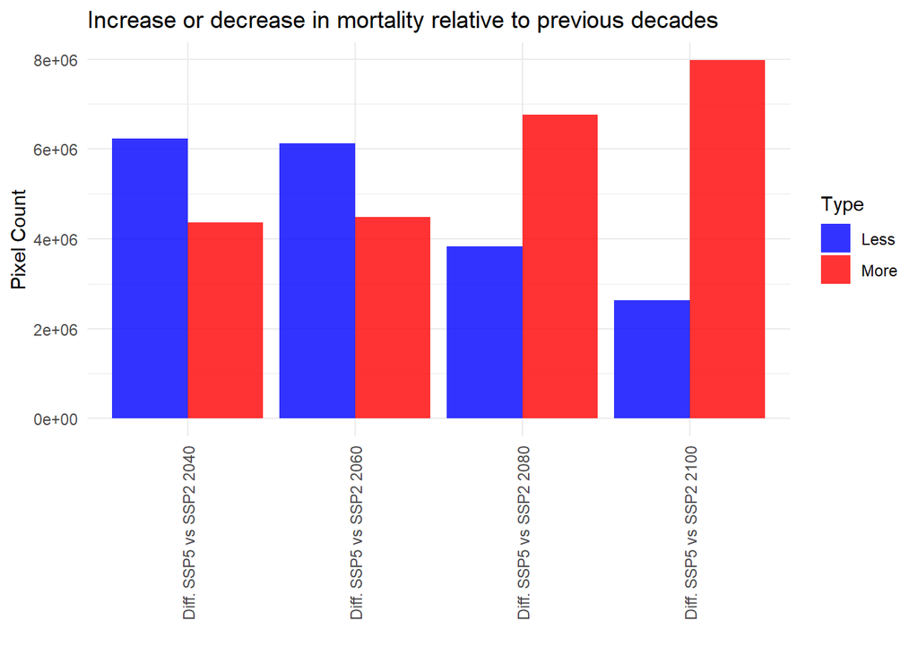

```r
# Load required libraries
library(terra)
library(ggplot2)



# Example raster files (replace these with your raster files)

r1 = raster_stack_preds[[2]] - raster_stack_preds[[1]]
r2 = raster_stack_preds[[4]] - raster_stack_preds[[3]]
r3 = raster_stack_preds[[6]] - raster_stack_preds[[5]]
r4 = raster_stack_preds[[8]] - raster_stack_preds[[7]]

# Function to count positive and negative pixels in a raster
count_pixels = function(raster, name) {
  values = values(raster)
  positive = sum(values > 0, na.rm = TRUE)
  negative = sum(values < 0, na.rm = TRUE)
  data.frame(
    Raster = name,
    Type = c("More", "Less"),
    Count = c(positive, negative)
  )
}

# Count pixels for each raster
df1 = count_pixels(r1, "Diff. SSP5 vs SSP2 2040")
df2 = count_pixels(r2, "Diff. SSP5 vs SSP2 2060")
df3 = count_pixels(r3, "Diff. SSP5 vs SSP2 2080")
df4 = count_pixels(r4, "Diff. SSP5 vs SSP2 2100")

# Combine results into one data frame
df = rbind(df1, df2, df3, df4)

# Create a bar plot
ggplot(df, aes(x = Raster, y = Count, fill = Type)) +
  geom_bar(stat = "identity", position = "dodge", alpha = 0.8) +
  labs(title = "Increase or decrease in mortality relative to previous decades", x = "", y = "Pixel Count") +
  scale_fill_manual(values = c("More" = "red", "Less" = "blue")) +
  theme_minimal()+
    theme(
    axis.text.x = element_text(angle = 90, vjust = 0.5, hjust = 1)
  )
```

### Animate differences

```r
diff_2040 <- raster_stack_preds[[2]] - raster_stack_preds[[1]]
diff_2060 <- raster_stack_preds[[4]] - raster_stack_preds[[3]]
diff_2080 <- raster_stack_preds[[6]] - raster_stack_preds[[5]]
diff_2100 <- raster_stack_preds[[8]] - raster_stack_preds[[7]]

# Define a custom blue-to-white-to-red color ramp
color_ramp <- colorRampPalette(c("blue", "white", "red"))

# Automatically calculate symmetric breaks around 0
max_abs_val <- max(abs(minmax(diff_2080)["max", ]), abs(minmax(diff_2080)["min", ]))
breaks <- seq(-max_abs_val, max_abs_val, length.out = 21)  # 20 intervals with 0 in the center


# Animation erstellen
titles_ssp5 = c("diff ssp5-ssp2 2040", "diff ssp5-ssp2 2060", "diff ssp5-ssp2 2080", "diff ssp5-ssp2 2100")

saveGIF({

  plot(diff_2040, main = titles_ssp5[1], col = color_ramp(length(breaks)-1), breaks = breaks)
  plot(diff_2060, main = titles_ssp5[2], col = color_ramp(length(breaks)-1), breaks = breaks)
  plot(diff_2080, main = titles_ssp5[3], col = color_ramp(length(breaks)-1), breaks = breaks)
  plot(diff_2100, main = titles_ssp5[4], col = color_ramp(length(breaks)-1), breaks = breaks)

}, movie.name = "dead_tree_animation.gif")
```

```
[1] TRUE
```

#### Histograms of tree species distribution over time

Let us now make a somewhat more comprehensive analysis. We want to inspect the distribution of tree mortality over time.

```r
# Load required libraries

# Raster files (replace these with your raster files)
r1 = raster_stack_preds[[c(2)]]/100
r2 = raster_stack_preds[[c(4)]]/100
r3 = raster_stack_preds[[c(6)]]/100
r4 = raster_stack_preds[[c(8)]]/100

# Function to prepare raster data for plotting
prepare_histogram_data = function(raster, name) {
  values = values(raster)  # Extract raster values
  values = values[!is.na(values)]  # Remove NA values
  data.frame(
    Value = values,
    Raster = name
  )
}

# Prepare data for all rasters
df1 = prepare_histogram_data(r1, "2040")
df2 = prepare_histogram_data(r2, "2060")
df3 = prepare_histogram_data(r3, "2080")
df4 = prepare_histogram_data(r4, "2100")

# Combine all data into one data frame
df = bind_rows(df1, df2, df3, df4)

# Check if the data frame is constructed correctly
head(df)
```

```
     Value Raster
1 21.52535   2040
2 21.52535   2040
3 30.99529   2040
4 19.61147   2040
5 19.60380   2040
6 22.92094   2040
```

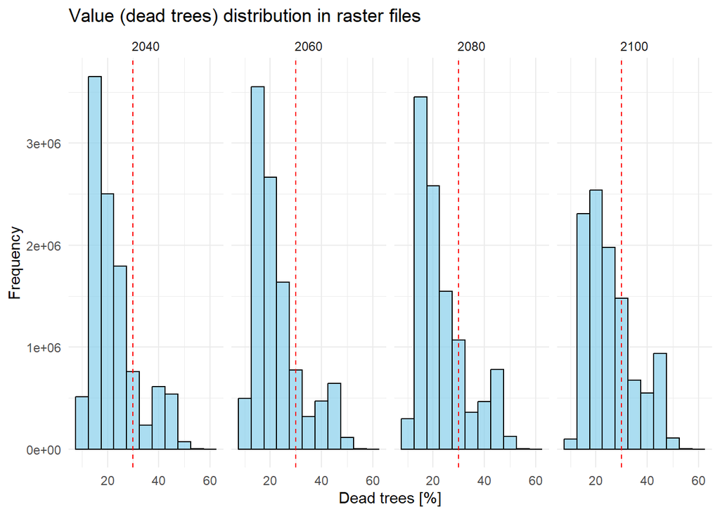

```r
# Create histograms with facets
ggplot(df, aes(x = Value)) +
  geom_histogram(binwidth = 5, fill = "skyblue", color = "black", alpha = 0.7) +
  geom_vline(xintercept = 30, color = "red", linetype = "dashed", linewidth = 0.5) + #e.g. threshold for dead pixels from Day 1
  facet_wrap(~ Raster, scales = "fixed", ncol = 4) +
  labs(title = "Value (dead trees) distribution in raster files", x = "Dead trees [%]", y = "Frequency") +
  theme_minimal()
```

#### Animation of tree species distribution

- A GIF can show how tree species mortality evolve over time, making it easier to observe trends, such as shifts due to climate change.
- GIFs are simple and engaging, making complex data more accessible to broader audiences, including policymakers, stakeholders, and the general public.

```r
library(animation)

# Define a custom color ramp
color_ramp = colorRampPalette(c("white", "orange", "red", "darkred"))

# Create breaks to emphasize values above 5000
breaks = c(0, 1000, 2000, 3000, 4000, 5000, 6000, 7000, 8000)

# Animation erstellen
titles_ssp5 = c("2040 ssp5", "2060 ssp5", "2080 ssp5", "2100 ssp5")

saveGIF({

  plot(raster_stack_preds[[c(2)]], main = titles_ssp5[1], col = color_ramp(length(breaks)-1), breaks = breaks)
  plot(raster_stack_preds[[c(4)]], main = titles_ssp5[2], col = color_ramp(length(breaks)-1), breaks = breaks)
  plot(raster_stack_preds[[c(6)]], main = titles_ssp5[3], col = color_ramp(length(breaks)-1), breaks = breaks)
  plot(raster_stack_preds[[c(8)]], main = titles_ssp5[4], col = color_ramp(length(breaks)-1), breaks = breaks)

}, movie.name = "dead_tree_animation.gif")
```

```
[1] TRUE
```

#### Interactive map of dead trees distribution using Leaflet

Leaflet allows users to explore the data interactively. They can zoom in, pan around, and focus on specific regions of interest.

```r
library(leaflet)
library(mapview)


template = rast(ext(raster_stack_preds[[8]]), crs = crs(raster_stack_preds[[8]]), resolution = 1000)  # 1000-meter resolution


# Resample raster to match the template's resolution
resampled_raster = resample(raster_stack_preds[[8]], template, method = "bilinear")

# Define a custom color palette
custom_palette <- colorNumeric(
  palette = c("green", "orange", "red", "darkred"),
  domain = values(resampled_raster),  # Define the range of values
  na.color = "transparent"  # Set NA values to transparent
)


leaflet() %>%
  addTiles() %>%
  addRasterImage(resampled_raster,
                 colors = custom_palette,
                 opacity = 0.8) %>%  # Apply custom colors
  addLegend(
    pal = custom_palette,
    values = values(resampled_raster),
    title = "Tree species 2100 SSP5",
    opacity = 0.8
  )
```

[interactive chart not shown]